# Čiščenje podatkov

## Datoteke iz statističnega urada

- https://www.stat.si/
- Meni zgoraj `Področja`, izberemo `Izobraževanje`, v podmeniju izberemo `Višješolsko, visokošolsko izobraževanje`.
- Nižje na strani najdemo razdelek `Več tabel v podatkovni bazi SI-STAT`, kliknemo `Izobraževanje`.
- Pomaknemo se za zaslon nižje na strani do drevesnega pogleda izberemo: `Razžiri vse`, `Izobraževanje`, `Višješolsko, visokošolsko izobraževanje`, `Vpisani v visokošolsko izobraževanje`, tabela s šifro `0955201S`.

## Izbor oblike podatkov

- Izberemo vse možnosti v 5 dimenzijah podatkov (razen agregatov `SKUPAJ`).
- Nižje pri gumbu `Izpis podatkov` izberemo `Prikaži tabelo na zaslonu, prikaz 2`.
- S pomočjo operacij vrtenja tabel spravimo podatke v željeno obliko in izvozimo.

## Tabele s hierarhičnimi indeksi

- Primer:

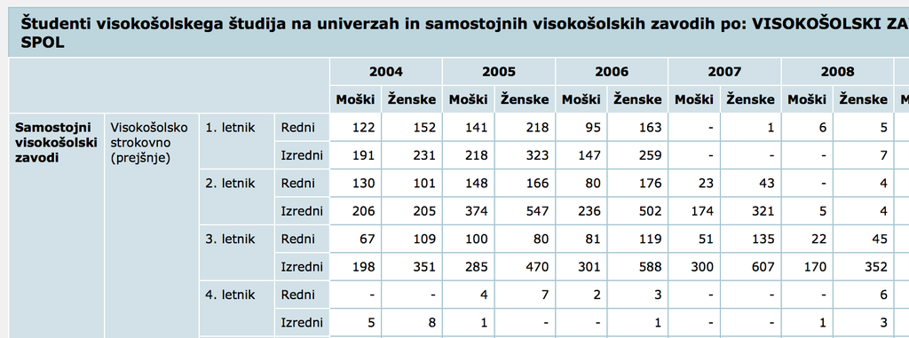

- S hierarhičnimi indeksi je težko delati.
- R nima dobre podpore (npr. Python Pandas ima).

## “Navadne tabele”

- Tabele poskušamo spraviti v obliko “ena meritev-ena vrstica”.
- Meritev je število vpisanih.
- Vsi drugi podatki določajo dimenzije, pri katerih je opravljena meritev.
- Tabelo želimo v taki obliki:
  - VISOKOŠOLSKI ZAVOD
  - VRSTA IZOBRAŽEVANJA
  - LETNIK
  - NAČIN ŠTUDIJA
  - ŠTUDIJSKO LETO
  - ST_STUDENTOV
- S takimi podatki je v R lažje delati.

## Obdelava in pridobivanje podatkov

- Ročno zavrtimo tabelo.
- Izvozimo v obliki `CSV (ločeno s podpičjem) z glavo`.
- Za namene demonstracije dela s čiščenjem podatkov, bomo uporabili še “staro” datoteko, ki ima še kompleksnejšo strukturo in dodatno dimenzijo `SPOL` (`viri/0955201ss.csv`).
- Ogledamo si format CSV v tekstovni datoteki.
- Ogledamo si še datoteko v Excelu.
- Prve 4 vrstice so nepomembne.
- Tabela nima glave.
- Vsebina v prvih nekaj stolpcih je še vedno podana hierarhično.
- Prazna polja so označena kot “-”

## Branje tabele

- Uporabili bom paket `readr`
- RStudio CheatSheets - https://www.rstudio.com/resources/cheatsheets/
- Pričakuje se, da na koncu predavanj obvladate cheatsheets-e Data Import, Data Transformation, RMarkdown, RStudio, Shiny, Data Visualization (skoraj vse :)
- Poskusimo naivno prebrati CSV datoteko

```r
uvoz <- read_csv2("0955201ss.csv")
```

- Problem: kodna tabela

```r
uvoz <- read_csv2("0955201ss.csv",
                  locale=locale(encoding="cp1250"))
```

## Branje tabele

- Problem? Pogledamo:

```r
problems(uvoz)
```

- Vizualno pregledamo, kaj se je uvozilo:

```r
View(uvoz)
```

## Branje tabele

- V uvozu imamo samo en stolpec!
- Definirajmo stolpce

```r
stolpci <- c("VISOKOSOLSKI_ZAVOD", "VRSTA_IZOBRAZEVANJA",
"LETNIK", "NACIN_STUDIJA", "SPOL" ,
"STUDIJSKO_LETO", "ST_STUDENTOV")
```

```r
uvoz <- read_csv2("0955201ss.csv",
                  locale=locale(encoding="cp1250"),
                  col_names=stolpci)
```

```r
problems(uvoz)
```

```r
View(uvoz)
```

## Branje tabele

- Izpustiti moramo prve 4 vrstice

```r
uvoz <- read_csv2("0955201ss.csv",
                  locale=locale(encoding="cp1250"),
                  col_names=stolpci,
                  skip=4)
```

- Zadnja prebrana vrstica (po branju), ki nas še zanima je 7162

```r
uvoz <- read_csv2("0955201ss.csv",
                  locale=locale(encoding="cp1250"),
                  col_names=stolpci,
                  skip=4,
                  n_max=7162)
```

## Branje tabele

- Znak “`-`” pri številu študentov bi radi interpretirali kot `NA`

```r
uvoz <- read_csv2("0955201ss.csv",
                     locale=locale(encoding="cp1250"),
                     col_names=stolpci,
                     skip=4,
                     n_max=7162,
                     na=c("", " ", "-"))
```

## Obdelava podatkov

- Zaradi ‘hierarhično kompresiranega uvoza’ bi radi, da se vsi dimenzijski stolpci ponavljajo v vrsticah do naslednjega vnosa
- Izjema je stolpec `STUDIJSKO_LETO`

```r
podatki <- uvoz %>%
      fill(1:5) %>%
      drop_na(STUDIJSKO_LETO)
```

## Pregled tipov stolpcev

- Preverimo tipe stolpcev

```r
sapply(podatki, class)
```

- Tipi so ustrezni.
- Če bi v kakšnem številskem stolpcu imeli kak “zatipk”, bi verjetno uvozili ta stolpec kot tip `character`.
- Tak stolpec bi najprej obdelali kot vektor nizov in potem stolpec pretvorili (npr. s funkcijo `parse_integer()` iz paketa `readr`).

## Relacijski model

- Podatke organiziramo kot množico večih tabel (`data.frame`-ov).
- Model je v osnovi star več kot 40 let.
- Uporablja se v večini večjih poslovnih sistemov, relacijskih podatkovnih bazah
- Enostaven za razumevanje, pregleden.
- Omogoča zmogljive poizvedbe v standardiziranem jeziku SQL (na podatkovnih bazah) in podobno zmogljive poizvedbe/operacije v R.
- Podpira učinkovite implementacije (pri podatkovnih bazah in v R).

## Relacijska algebra

- Podatke organiziramo kot množico večih tabel (`data.frame`-ov)
- *Relacija* = tabela
- *Relacijska algebra* je matematični opis operacij nad relacijami (tabelami).
- Operatorji so operacije, ki sprejmejo relacije (tabele) in vrnejo (nove) relacije (tabele).
- *Shema relacije* = definicija tabele (imena + tipi).

## Operatorji relacijske algebre

- Operatorji so odvisni od shem relacij nad katerimi jih izvajamo.
- \(\sigma_{p}(R)\) - izberi vrstice v relaciji \(R\), ki ustrezajo pogoju \(p\).
  - Pogoj je lahko logični izraz.
  - Shema vrnjene tabele je ista.
  - Primer: operator `[pogoj,]` v kombinaciji z logičnim indeksom
- \(\pi_{a_1, a_2, \ldots, a_n}(R)\) - izberi stolpce z imeni \(a_1, a_2, \ldots, a_n\) relacije \(R\) in vrni novo tabelo s shemo, ki jo določajo definicije teh stolpcev.
  - Število vrstic ostane nespremenjeno.
  - Primer: operator `[vektor_imen]`.

## Operatorji relacijske algebre

- \(\rho_{a/b}(R)\) - spremeni ime stolpcu \(a\) v \(b\). Vrni enako tabelo (glede vrstic), le z drugo shemo.
  - Primer: preimenovanje stolpca.
- \(R \cup S\) - vrni relacijo z unijo vrstic, če imata relaciji \(R\) in \(S\) enaki shemi.
- \(R \setminus S\) - vrni relacijo z razliko vrstic, če imata relaciji \(R\) in \(S\) enaki shemi.
- \(R \times S\) - vrni kartezični produkt relacij (vsaka vrstica \(R\) z vsako vrstico \(S\)).
  - Shema rezultata sta združeni shemi.
  - Ni tako uporabna operacija, so pa uporabne ustrezne učinkovite izvedbe s filtriranjem (združitve).

## Operacija JOIN

\(R \bowtie S = \pi_{\scriptsize shema(R) \cup shema(S)}( \sigma_{\scriptsize R.a_1 = S.a_1 \land R.a_2 = R.a_2 \land \ldots}(R \times S))\)

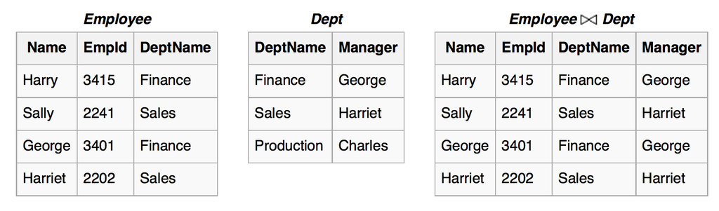

Vir: Wikipedia.

- “Sklic” med tabelami.
- Levi join, desni join, navaden join.

## Paket *dplyr*

- Podpira operacije iz relacijske algebre.
- Učinkovita implementacija.
- Alternativa: uporaba paketa `data.table`
- https://cran.rstudio.com/web/packages/dplyr/vignettes/introduction.html
- https://cran.r-project.org/web/packages/dplyr/vignettes/two-table.html

## Operatorji v *dplyr*

- Osnovni relacijski operatorji:
  - `filter(p)` - \(\sigma_{p}(R)\)
  - `select(a_1, a_2, ..., a_n)` - \(\pi_{a_1, a_2, \ldots, a_n}(R)\)
  - `rename()` - \(\rho_{a/b}(R)\)
  - `union(x, y)` - \(R \cup S\)
  - `setdiff(x, y)` - \(R \setminus S\)
  - `inner_join(x, y)` - združitev po skupnih stolpcih
- Dodatni praktično uporabni operatorji
  - `arrange(...)` - urejanje vrstic glede na izbrane stolpce
  - `mutate(...)` - preimenovanje stolpcev in dodajanje novih, ki so funkcije obstoječih.
  - `distinct()` - ohranjanje enoličnih vrstic
  - `summarize(...)` - uporaba združevalne funkcije na nekem stolpcu
  - `group_by(...)` - združevanje po vrsticah glede na enake vrednosti v stolpcih

## Popravljanje stolpca `LETNIK`

- V stolpcu `LETNIK` bi želeli krajši zapis
- Poglejmo kaj imamo v stolpcu (histogram)

```r
table(podatki$LETNIK)
```

- Obstoječa imena v stolpcu `LETNIK`

```r
> imena <- c("1. letnik", "2. letnik", "3. letnik",
"4. letnik", "5. letnik", "6. letnik", "Absolventi")
```

- Radi bi jih poenostavili imena v:

```r
> letniki <- c("1","2","3","4","5","6","Abs")
```

## Popravljanje stolpca `LETNIK`

- Ustvarimo “relacijo” s temi dvemi stolpci.

```r
> tab2 <- data.frame(
    letnik=letniki,
    ime=imena,
    stringsAsFactors = FALSE)
```

- Uporabimo operacijo `inner_join` po stolpcih `LETNIK` IN `ime`

```r
> require(dplyr)
> zdruzena <- podatki %>%
    inner_join(tab2, c("LETNIK"="ime"))
```

- Lahko bi še odstranili stolpec `LETNIK` in stolpec `letnik` preimenovali …

## Poizvedbe

- Uporabi operacije iz relacijske algebre pravimo *poizvedba*.
- Ime izhaja iz relacijskih podatkovnih baz in jezika SQL, ki izvaja operacije in iz obstoječih tabel (relacij) preko operacij proizvajajo nove tabele (relacije).
- Vrni tabelo z vrsticami, ki pripadajo ženskam.

```r
> filter(zdruzena, SPOL=="Ženske")
```

- Ekvivalentno operatorju `[pogoj,]`
- Bolj po dplyr-jevsko:

```r
> zdruzena %>% filter(SPOL=="Ženske")
```

## Poizvedbe

- Vse vrstice, v katerih so ženske vpisane po letu 2011.

```r
> zdruzena %>% filter(SPOL=="Ženske" &
    STUDIJSKO_LETO > 2011)
```

- Namesto operatorja “&” lahko pogoje ločimo z vejico.

```r
> zdruzena %>% filter(SPOL=="Ženske",
    STUDIJSKO_LETO > 2011)
```

## Operacija `arrange`

- Uredi po stolpcu `ST_STUDENTOV`.

```r
> zdruzena %>% arrange(ST_STUDENTOV)
```

- Uredi po stolpcih `STUDIJSKO_LETO` in potem po stolpcu `ST_STUDENTOV`, in sicer padajoče.

```r
> zdruzena %>% arrange(STUDIJSKO_LETO, desc(ST_STUDENTOV))
```

## Operaciji `select` in `rename`

- Izberi samo stolpce `STUDIJSKO_LETO`, `ST_STUDENTOV` in `SPOL`

```r
> zdruzena %>%
    select(STUDIJSKO_LETO, ST_STUDENTOV, SPOL)
```

- Ob tem še preimenuj stolpec `STUDIJSKO_LETO` v `LETO`.

```r
> zdruzena %>%
    select(LETO=STUDIJSKO_LETO, ST_STUDENTOV, SPOL)
```

- Preimenuj stolpec `STUDIJSKO_LETO` v `LETO`

```r
> zdruzena %>% rename(LETO=STUDIJSKO_LETO)
```

## Združevanje po vrsticah

- Za katera leta imamo podatke?

```r
> zdruzena %>%
      select(STUDIJSKO_LETO) %>%
      distinct()
```

- Koliko študentov je bilo vpisanih vsako leto?

```r
> zdruzena %>%
    group_by(STUDIJSKO_LETO) %>%
    summarize(VPIS=sum(ST_STUDENTOV, na.rm=TRUE))
```

## Združevanje po vrsticah

- Najprej smo združili vrstice po istih vrednostih v stolpcu `STUDIJSKO_LETO`, potem pa uporabili združevalno funkcijo na nekem od preostalih stolpcev.
- V rezultatu so le smiselni stolpci.
- Združevalne funkcije: `min(x)`, `max(x)`, `mean(x)`, `sum(x)`, `sd(x)`, `median(x)`, `n(x)`, `n_distinct(x)`, `first(x)`, `last(x)` in `nth(x, n)`

## Združevanje

- Koliko je bilo vpisanih po spolih za posamezna leta?

```r
> zdruzena %>%
    group_by(SPOL, STUDIJSKO_LETO) %>%
    summarize(VPIS=sum(ST_STUDENTOV, na.rm=TRUE))
```

## Združevanje

- Koliko žensk in koliko moških je bilo vpisanih na posameznih vrstah študija na univerzi in kakšni so njihovi deleži?

```r
> zdruzena %>%
  filter(VISOKOSOLSKI_ZAVOD == "Univerze - SKUPAJ") %>%
  select(VRSTA_IZOBRAZEVANJA, SPOL, ST_STUDENTOV) %>%
  group_by(VRSTA_IZOBRAZEVANJA, SPOL) %>%
  summarize(STEVILO=sum(ST_STUDENTOV, na.rm=TRUE)) %>%
  pivot_wider(names_from=SPOL, values_from=STEVILO) %>%
  arrange(VRSTA_IZOBRAZEVANJA) %>%
  mutate(
    deležMoški=round(Moški/(Moški + Ženske), 2),
    deležŽenske=round(Ženske/(Moški + Ženske), 2)
  )
```

## Organizacija podatkov

- Podatke si skušamo organizirati v obliko, ki se ji reče [Tidy data](https://cran.r-project.org/web/packages/tidyr/vignettes/tidy-data.html).
- Stolpci lahko predstavljajo spremenljivke ali meritve.
- Spremenljivke opisujejo parametre pri katerih je izvedene meritev (“dimenzije”).
- Definicija “Tidy data”:
  - vsaka spremenljivka tvori stolpec,
  - za vsako meritev imamo eno vrstico,
  - vsak tip meritve je v ločeni tabeli.

## Najbolj pogosti problemi

- Imena stolpcev so vrednosti, ne pa imena spremenljivk.
- V enem stolpcu hranimo več spremenljivk.
- Spremenljivke hranimo tako v vrsticah kot v stolpcih.
- Več vrst meritev (podatkov) v eni tabeli.
- Več istovrstnih meritev v večih tabelah.
- Hadley Wickham, [Tidy Data](http://www.jstatsoft.org/article/view/v059i10/v59i10.pdf), Journal of Statistical Software, August 2014, Volume 59, Issue 10

## Imena stolpcev so vrednosti

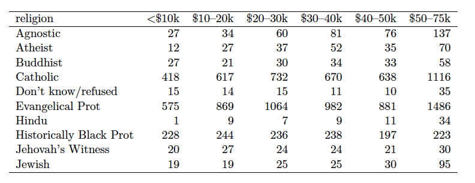

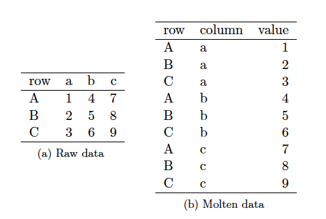

## Operacija “pivot_longer”

- paket `tidyr`
- alternative `gather (tidyr)`, `melt (reshape2)`

```r
head(airquality)
```

```
##   Ozone Solar.R Wind Temp Month Day
## 1    41     190  7.4   67     5   1
## 2    36     118  8.0   72     5   2
## 3    12     149 12.6   74     5   3
## 4    18     313 11.5   62     5   4
## 5    NA      NA 14.3   56     5   5
## 6    28      NA 14.9   66     5   6
```

## Operacija “pivot_longer”

```r
airquality %>%
  pivot_longer(
    c(-Month, -Day),
    names_to="MERITEV",
    values_to="VREDNOST"
  ) %>% head
```

```
## # A tibble: 6 x 4
##   Month   Day MERITEV VREDNOST
##   <int> <int> <chr>      <dbl>
## 1     5     1 Ozone       41
## 2     5     1 Solar.R    190
## 3     5     1 Wind         7.4
## 4     5     1 Temp        67
## 5     5     2 Ozone       36
## 6     5     2 Solar.R    118
```

## En stolpec več spremenljivk

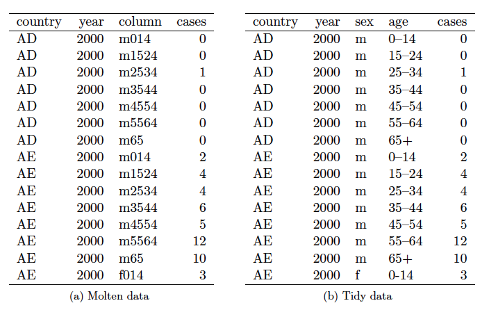

- Obdelavo nizov si bomo ogledali kasneje (regularni izrazi)

## Spremenljivke v vrsticah in stolpcih

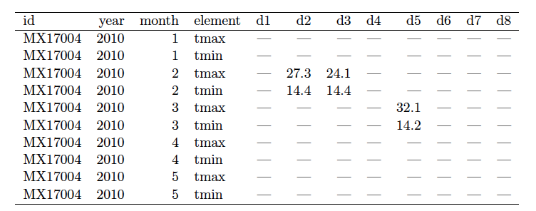

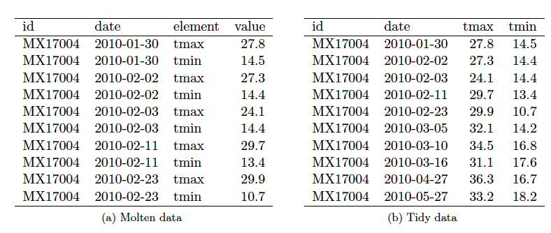

## Več vrst meritev v eni tabeli

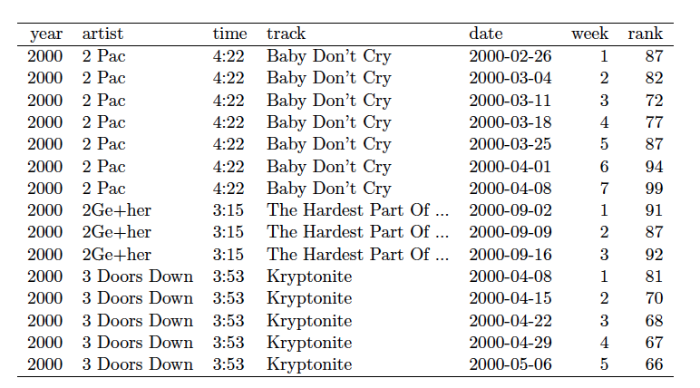

- Vsaka meritev v svoji tabeli (normalizacija).

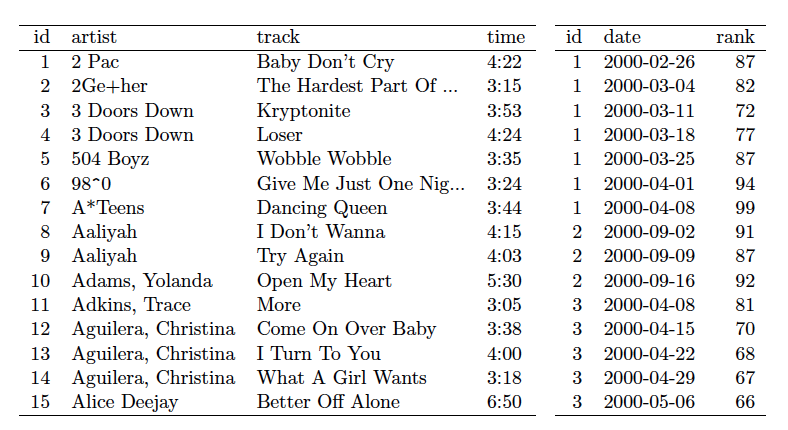

## Več istovrstnih meritev v večih tabelah

- Npr. meritve za vsako leto, po osebah, …
- Po potrebi dodamo stolpce, ki odražajo delitev in združimo v eno tabelo.
- Npr. delitev po letih: dodamo stolpec leto.